# Comparison of SAEM to multiple imputation methods on trauma data

## Miscellaneous setup

Imports

```r
## Imports
library(tidyverse)
library(verification)

# Custom imports
aux.folder = '../auxiliary/'
source(paste(aux.folder,'dataloaders.R',sep=''), chdir = T)
source(paste(aux.folder,'generate_missing.R',sep=''), chdir = T)
source(paste(aux.folder,'imputation_methods.R',sep=''), chdir = T)
source(paste(aux.folder,'prediction_methods.R',sep=''), chdir = T)
```

Parameters for this run

```r
seed = 42
dataset = 'trauma'
prop_added_missing = 0
n_imputations = 5
prediction_method = 'rf'
train_size = 0.5
max_rows = NULL
```

## Data preparation

Import and select columns

```r
# Load and format the dataset
dat = loader(dataset, max_rows, seed)
```

```
## [1] "Loading trauma data..."
## [1] "Imported  14  numerical variables ( 18.5812273545564 % missing entries), and  23  categorical variables ( 24.6478531351648 % missing entries)."
## [1] "Done (6269 rows)."
```

```r
X = dat$X_numeric # For now we keep only a subset of the given data, as in Wei's work
X = X %>% dplyr::select(Age, Glasgow.moteur.initial, FC.max, Hemocue.init, Remplissage.total.cristalloides, Remplissage.total.colloides,
                        SD.min, SD.SMUR)
y=dat$y
```

Add some missing values (or not)

```r
X_miss = MCAR(X, prop_added_missing)
```

```
## [1] "Adding 0% missing observations completely at random."
## [1] "New proportion of missing data: 19.0361301643005%."
## [1] "Done."
```

## Prediction

### SAEM Prediction

```r
prediction_SAEM = saem_prediction(X_miss, y, train_size=train_size, seed=seed, printevery=50)
```

```
## [1] "Predicting response using SAEM logistic regression on 50% of the data as training set..."
## iteration = 50 beta = -0.1104064 0.0119905 -0.1236841 0.0316608 -0.3021169 0.0007759611 0.001630179 -0.02374625 -0.02523369
## Distance from estimator from last iter = 0.0003684515
## iteration = 100 beta = -0.2300485 0.01178582 -0.1149982 0.03239869 -0.3085506 0.0008229189 0.00166179 -0.02709338 -0.02124755
## Distance from estimator from last iter = 2.165192e-06
```

### Imputed prediction

Perform multiple imputation

```r
X_imputed = mice_imp(X_miss, m=n_imputations)
```

```
## [1] "Performing 5 imputations with MICE..."
## [1] "Done."
```

Perform imputaton by the mean

```r
X_fillmean = X_miss
for(i in 1:ncol(X_fillmean)){
  c = X_fillmean[,i]
  X_fillmean[is.na(c),i] = mean(c, na.rm = T)
}
```

Fit and predict on each filled dataset using the same train/test split as with the SAEM. Here the prediction is made using any method available for caret (the choice is made at the top of the document. Here, we use a random forest estimator with no parameter tuning.)

```r
predictions = multiple_prediction(X_imputed, y, pred_method = prediction_method,
                                  train_size = train_size, seed=seed, spl=prediction_SAEM$spl)
```

```
## [1] "Predicting response using method rf on 50% of the data as training set..."
## [1] "Existing train/test split provided. Ignoring train_size parameter."
## [1] "Processing imputed dataset 1"
## [1] "Processing imputed dataset 2"
## [1] "Processing imputed dataset 3"
## [1] "Processing imputed dataset 4"
## [1] "Processing imputed dataset 5"
## [1] "Done."
```

Perform a single prediction on the filled dataset with the mean

```r
prediction_meanfill = multiple_prediction(list(X_fillmean), y, pred_method = prediction_method,
                                          train_size = train_size, seed=seed,spl=prediction_SAEM$spl)
```

```
## [1] "Predicting response using method rf on 50% of the data as training set..."
## [1] "Existing train/test split provided. Ignoring train_size parameter."
## [1] "Processing imputed dataset 1"
## [1] "Done."
```

## Result aggregation and comparison

Compute the average predictor for multiple imputation and regroup all the predictions in a table

```r
y_pred = matrix(NA, nrow=length(predictions$y_true), ncol=n_imputations)
for(i in 1:n_imputations){
  y_pred[,i] = predictions$y_pred[[i]][,2]
}
results = data.frame(row.names=1:nrow(y_pred))
results$MI_estimate = apply(y_pred, 1, mean)
results$SAEM_estimate = prediction_SAEM$y_pred
results$meanImp_estimate = prediction_meanfill$y_pred[[1]][,2]
results$Hemo.shock = as.numeric(predictions$y_true == 'X1')

print('Estimations of the probability of hemorragic shock by various methods')
```

```
## [1] "Estimations of the probability of hemorragic shock by various methods"
```

```r
head(results)
```

```
##   MI_estimate SAEM_estimate meanImp_estimate Hemo.shock
## 1      0.0252   0.025626564            0.000          0
## 2      0.0008   0.011983082            0.000          0
## 3      0.0388   0.030227844            0.004          0
## 4      0.0080   0.005218653            0.010          0
## 5      0.0828   0.032185567            0.016          0
## 6      0.1272   0.009908251            0.194          0
```

Plot the ROC curve for these estimators. The number in the legend is the AUC (are under the ROC curve) for each model.

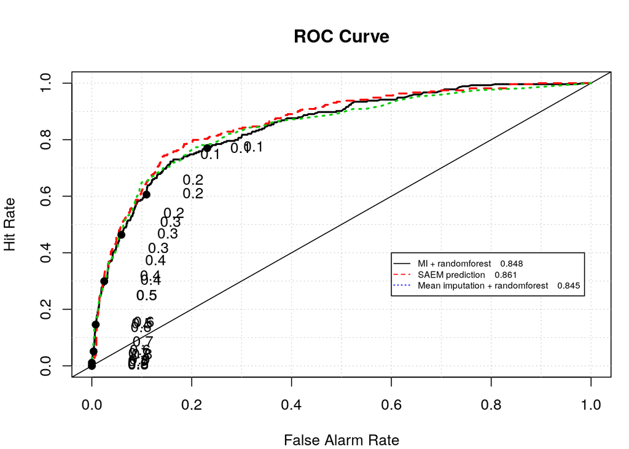

```r
roc.plot(results$Hemo.shock, results[,c(1,2,3)], legend=T, leg.text=c("MI + randomforest", 'SAEM prediction', "Mean imputation + randomforest"))
```

In this case, the results are extremely similar. It is interesting to note that when we restrics the dataset to 1000 entries, the SAEM logistic regression performs significantly better than the other methods. In our work to come, we will try to see how this performance discrepancy evolves when we increase the amount of missing data, as well as the performance of other imputation methods.